# Project: No-Show Appointments Data Analisis

### Is there a correlation between Neighborhood and No-Show?

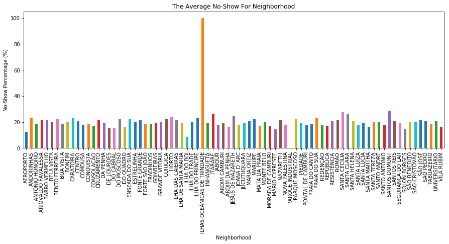

```python
no_nei = df.groupby('Neighborhood')['No-show'].mean()*100
no_nei.plot(kind=('bar'), stacked=False,yticks = range(0,120,20), figsize=(15,5))
plt.title('the average No-show for Neighborhood'.title())
plt.xlabel('Neighborhood'.title())
plt.ylabel('No-show percentage (%)'.title());
```

- **ILHAS OCEÂNICAS DE TRINDADE** have the **maximum no-show (100%)**.
- **PARQUE INDUSTRIAL** have the **minimum no-show (0%)**.
- **In general there is no correlation between neighborhood and no-show.**

### Is there a correlation between Gender and No-Show?

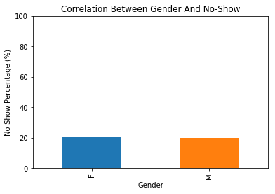

```python
no_gen = df.groupby('Gender')['No-show'].mean()*100
no_gen.plot(kind=('bar'),yticks = range(0,120,20))
plt.title('correlation between Gender and No-show'.title())
plt.xlabel('Gender'.title())
plt.ylabel('No-show percentage (%)'.title());
```

- The no-show rate for both genders looks roughly the same.
- **There is no correlation between genders and no-show.**

### Is there a correlation between Scholarship and No-Show ?

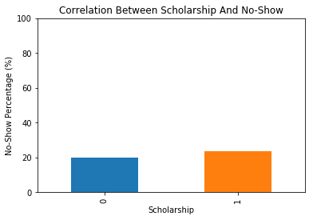

```python
no_sch = df.groupby('Scholarship')['No-show'].mean()*100
no_sch.plot(kind=('bar'), yticks = range(0,120,20))
plt.title('correlation between Scholarship and No-show'.title())
plt.xlabel('Scholarship'.title())
plt.ylabel('No-show percentage (%)'.title());
```

- **The rate of no-show increases for patients who have scholarship.**

### Is there a correlation between Hypertension and No-Show

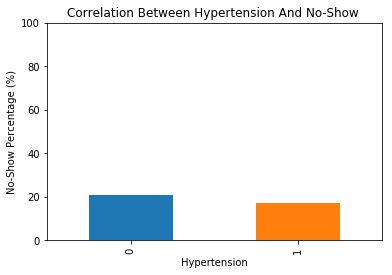

```python
no_hyp = df.groupby('Hypertension')['No-show'].mean()*100
no_hyp.plot(kind=('bar'), yticks = range(0,120,20))
plt.title('correlation between Hypertension and No-show '.title())
plt.xlabel('Hypertension'.title())
plt.ylabel('No-show percentage (%)'.title());
```

- **The rate of no-show in patients with Hypertension is lower than in patients without.**

### Is there a correlation between Diabetes and No-Show ?

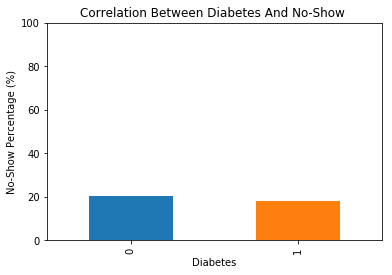

```python
no_dia = df.groupby('Diabetes')['No-show'].mean()*100
no_dia.plot(kind=('bar'), yticks = range(0,120,20))
plt.title('correlation between Diabetes and No-show '.title())
plt.xlabel('Diabetes'.title())
plt.ylabel('No-show percentage (%)'.title());
```

- **The rate of no-show in patients with Diabetes is lower than in patients without.**